## STAT 689 Homework 7

### Rohan Tiwari

```r
setwd("~/tamu/MS-STAT-2022/689-flexible-regression")
framingham = read.csv("framingham.csv")
head(framingham)
```

```
##   OBS Age SBP21 SBP22 SBP31 SBP32 Smoker Cholest2 Cholest3 CHD
## 1   1  56   110   120   136   134      0      276      295   0
## 2   2  38   118   126   120   114      1      211      255   0
## 3   3  54   140   120   125   124      1      284      287   0
## 4   4  42   122   116   115   110      1      225      285   0
## 5   5  47   136   134   130   144      1      292      240   0
## 6   6  43   138   120   118   110      1      192      208   0
```

```r
framingham$LSBP = log(apply(framingham[,c("SBP22" , "SBP21" ,"SBP31" ,"SBP32")], 1,mean) - 50)
framingham$Lcholest = log(apply(framingham[,c("Cholest2" , "Cholest3" )], 1,mean))
```

### 1. Fit an ordinary logistic regression with response = CHD, and predictor = Age. Show the summary table.

```r
library(mgcv)
ordinaryglmfit = gam(CHD ~ Age, family = binomial(link=logit), data = framingham)
summary(ordinaryglmfit)
```

```
##
## Family: binomial
## Link function: logit
##
## Formula:
## CHD ~ Age
##
## Parametric coefficients:
##             Estimate Std. Error z value Pr(>|z|)
## (Intercept) -5.46397    0.55630  -9.822  < 2e-16 ***
## Age          0.06298    0.01103   5.711 1.12e-08 ***
## ---
## Signif. codes:  0 '***' 0.001 '**' 0.01 '*' 0.05 '.' 0.1 ' ' 1
##
##
## R-sq.(adj) =  0.0183   Deviance explained = 3.81%
## UBRE = -0.46475  Scale est. = 1         n = 1615
```

### 2. In Question 1, display the fit without the data points. Just plot the model object. We know that when plotting the model object, mgcv::gam ignored the intercept.

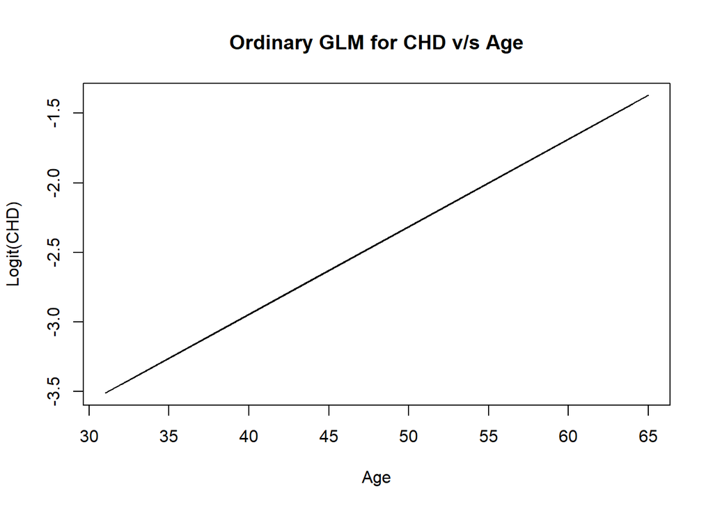

```r
fHatCHD = predict(ordinaryglmfit,
                    newdata = data.frame(Age = framingham$Age),
                    type="link")
plot(framingham$Age, fHatCHD, type = "l", xlab = "Age", ylab = "Logit(CHD)",
     main = "Ordinary GLM for CHD v/s Age")
```

### 3. In Question 1, is the fit statistically significant?

Looking at the summary output from question 1, the the fit is statistically significant at 0.05 looking at the p-value of age which is small.

### 4. In Question 1, test whether the fit is linear or quadratic versus the need to do a semiparametric fit, i.e., a spline in age

```r
#quadratic
glmfitquadratic = gam(CHD ~ Age + I(Age^2), family = binomial(link=logit), data = framingham)
#semiparametric
library(mgcv)
semiparametricglm = gam(CHD ~ s(Age,bs="cr",k=15) , data = framingham, family = binomial(link="logit"))
anova(ordinaryglmfit, glmfitquadratic, semiparametricglm, test = "Chisq")
```

```
## Analysis of Deviance Table
##
## Model 1: CHD ~ Age
## Model 2: CHD ~ Age + I(Age^2)
## Model 3: CHD ~ s(Age, bs = "cr", k = 15)
##   Resid. Df Resid. Dev     Df Deviance Pr(>Chi)
## 1    1613.0     860.43
## 2    1612.0     855.16 1.0000   5.2710  0.02168 *
## 3    1610.9     853.53 1.0705   1.6261  0.21901
## ---
## Signif. codes:  0 '***' 0.001 '**' 0.01 '*' 0.05 '.' 0.1 ' ' 1
```

Quadratic is an improvement over ordinary model and spline is not an improvement over quadratic. We do not need to do a spline in Age.

### 5. Fit a logistic gam with all the predictors but only LSBP modeled as a spline. a. Quote the p-values for all of the predictors.

```r
framingham.gam.logistic.lspbspline = gam(CHD ~ Age + as.factor(Smoker) + Lcholest + s(LSBP , bs = "cr"), family = binomial (link = "logit"), data = framingham)
summary(framingham.gam.logistic.lspbspline)
```

```
##
## Family: binomial
## Link function: logit
##
## Formula:
## CHD ~ Age + as.factor(Smoker) + Lcholest + s(LSBP, bs = "cr")
##
## Parametric coefficients:
##                     Estimate Std. Error z value Pr(>|z|)
## (Intercept)        -20.33917    3.28985  -6.182 6.31e-10 ***
## Age                  0.05673    0.01190   4.767 1.87e-06 ***
## as.factor(Smoker)1   0.60476    0.25094   2.410    0.016 *
## Lcholest             2.67952    0.57842   4.632 3.61e-06 ***
## ---
## Signif. codes:  0 '***' 0.001 '**' 0.01 '*' 0.05 '.' 0.1 ' ' 1
##
## Approximate significance of smooth terms:
##           edf Ref.df Chi.sq  p-value
## s(LSBP) 1.738    2.2  16.06 0.000537 ***
## ---
## Signif. codes:  0 '***' 0.001 '**' 0.01 '*' 0.05 '.' 0.1 ' ' 1
##
## R-sq.(adj) =  0.0432   Deviance explained = 9.17%
## UBRE = -0.48979  Scale est. = 1         n = 1615
```

p-values are given in the previous output.

### 5b. Answer whether the fit suggests that LSBP should be modeled as a spline. Remember, you need to do an ANOVA for this will the null model having everything modeled as ordinary logistic regression.

```r
framingham.gam.logistic.nullmodel = gam(CHD ~ Age + as.factor(Smoker) + Lcholest + LSBP, family = binomial (link = "logit"), data = framingham)
summary(framingham.gam.logistic.nullmodel)
```

```
##
## Family: binomial
## Link function: logit
##
## Formula:
## CHD ~ Age + as.factor(Smoker) + Lcholest + LSBP
##
## Parametric coefficients:
##                     Estimate Std. Error z value Pr(>|z|)
## (Intercept)        -27.85651    3.65619  -7.619 2.56e-14 ***
## Age                  0.05580    0.01188   4.697 2.64e-06 ***
## as.factor(Smoker)1   0.60901    0.25134   2.423   0.0154 *
## Lcholest             2.73540    0.57715   4.740 2.14e-06 ***
## LSBP                 1.66356    0.42118   3.950 7.82e-05 ***
## ---
## Signif. codes:  0 '***' 0.001 '**' 0.01 '*' 0.05 '.' 0.1 ' ' 1
##
##
## R-sq.(adj) =  0.042   Deviance explained = 8.92%
## UBRE = -0.48931  Scale est. = 1         n = 1615
```

```r
anova(framingham.gam.logistic.nullmodel, framingham.gam.logistic.lspbspline, test = "Chisq")
```

```
## Analysis of Deviance Table
##
## Model 1: CHD ~ Age + as.factor(Smoker) + Lcholest + LSBP
## Model 2: CHD ~ Age + as.factor(Smoker) + Lcholest + s(LSBP, bs = "cr")
##   Resid. Df Resid. Dev     Df Deviance Pr(>Chi)
## 1    1610.0     814.76
## 2    1608.8     812.52 1.2004   2.2489   0.1691
```

We should not model LSBP as spline as the second model in anova is not statistically significant improvement at 0.05.

### 6. Fit a logistic gam with LSBP, Lcholest and age modeled as splines. Quote the p-values for all predictors. Tell me which of the spline terms seem like they are worth modeling as a spline. Remember, you need to do an ANOVA for this will the null model having everything modeled as ordinary linear logistic regression, but use mgcv::gam.

```r
framingham.fit.gam.logistic.multspline = gam(CHD ~ s(Lcholest , bs = "cr") + as.factor(Smoker) + s(LSBP , bs = "cr") + s(Age , bs = "cr"), family = binomial (link = "logit"), method = "REML",
                                            data = framingham)
summary(framingham.fit.gam.logistic.multspline)
```

```
##
## Family: binomial
## Link function: logit
##
## Formula:
## CHD ~ s(Lcholest, bs = "cr") + as.factor(Smoker) + s(LSBP, bs = "cr") +
##     s(Age, bs = "cr")
##
## Parametric coefficients:
##                    Estimate Std. Error z value Pr(>|z|)
## (Intercept)         -3.2545     0.2459 -13.233   <2e-16 ***
## as.factor(Smoker)1   0.5913     0.2507   2.359   0.0183 *
## ---
## Signif. codes:  0 '***' 0.001 '**' 0.01 '*' 0.05 '.' 0.1 ' ' 1
##
## Approximate significance of smooth terms:
##               edf Ref.df Chi.sq  p-value
## s(Lcholest) 1.001  1.002  20.45 7.11e-06 ***
## s(LSBP)     1.766  2.238  16.34 0.000507 ***
## s(Age)      2.271  2.839  23.36 4.45e-05 ***
## ---
## Signif. codes:  0 '***' 0.001 '**' 0.01 '*' 0.05 '.' 0.1 ' ' 1
##
## R-sq.(adj) =  0.0447   Deviance explained = 9.75%
## -REML = 406.99  Scale est. = 1         n = 1615
```

```r
anova(framingham.gam.logistic.nullmodel, framingham.fit.gam.logistic.multspline, test = "Chisq")
```

```
## Analysis of Deviance Table
##
## Model 1: CHD ~ Age + as.factor(Smoker) + Lcholest + LSBP
## Model 2: CHD ~ s(Lcholest, bs = "cr") + as.factor(Smoker) + s(LSBP, bs = "cr") +
##     s(Age, bs = "cr")
##   Resid. Df Resid. Dev     Df Deviance Pr(>Chi)
## 1    1610.0     814.76
## 2    1605.9     807.33 4.1202   7.4302   0.1229
```

p-values are given in the previous output.

The model with splines does not seem to be an improvement because it is not statistically significant at 0.05 compared to the null model.